# 0.0. Introduction to Statistics

Welcome to Statistical Methods for Machine Learning. The field of statistics is hundreds of years old and statistical methods are central to working through predictive modeling problems with machine learning. Statistics is a collection of tools that you can use to get answers to important questions about data. You can use descriptive statistical methods to transform raw observations into information that you can understand and share. You can use inferential statistical methods to reason from small samples of data to whole domains.

In this module, you will discover clearly why statistics is important in general and for machine learning and generally the types of methods that are available.

Here, you will know:

- Statistics is generally considered a prerequisite to the field of applied machine learning.
- We need statistics to help transform observations into information and to answer questions about samples of observations.
- Statistics is a collection of tools developed over hundreds of years for summarizing data and quantifying properties of a domain given a sample of observations.

We designed this course to teach you step-by-step the basics of statistical methods with concrete and executable examples in Python.

Prerequisites:

- You know your way around basic Python for programming.
- You may know some basic NumPy for array manipulation.
- You want to learn statistical methods to deepen your understanding and application of machine learning.

Machine learning and statistics are two tightly related fields of study. So much so that statisticians refer to machine learning as applied statistics or statistical learning rather than the computer-science-centric name.

- Statistics allow researchers to collect information, or data, from a large number of people and then summarize their typical experience.
- Statistics are also used to reach conclusions about general differences between groups.
- Statistics can also be used to see if scores on two variables are related and to make predictions.

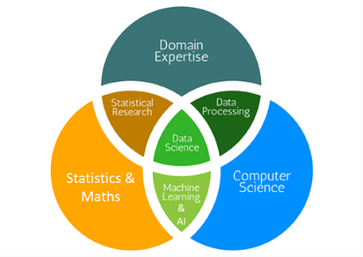

# 0.1. Types of Data

When working with statistics, it’s important to recognize the different types of data. Data are the actual pieces of information that you collect through your study.

## Numerical and Categorical

Most data fall into one of two groups: numerical or categorical.

Numerical data is information about quantities i.e., information that can be measured or counted and written down with numbers e.g., heights, ages, BMI, IQ, number of students in a class. Statisticians also call numerical data as **Quantitative data**. A quantitative variable can be either discrete or continuous.

Categorical data represent a quality or characteristics e.g., gender, marital status, employment status of an individual. Statisticians also call categorical data as **Qualitative data**.

*It should be noted that although categorical data can be expressed as numerical values (such as “1” indicating male and “0” indicating female) for the sake of computation, but those numbers don’t have mathematical meaning.*

Catergorical data can be further broken into two types: Nominal and Ordinal data.

### Discrete and Continuous

When we study data regarding quantitative values, it is immediately found that these may be of two principal types: Discrete and Continuous.

First, the data may take only some distinct or isolated values, like the number of letters on a word, number of members in a family. A variable that can assume only some distinct values in an interval is called as Discrete variable (data). In discrete data numeric values have a clear quantitative interpretation, e.g., no. of students in a particular class, no. of sections in a school, no. of brothers or sisters etc.

On the other hand, a variable which in theory is capable of taking any value in its range of variation or an interval is a continuous variable (data), We say “in theory” simply because we are limited by the precision of the measuring instrument for example, a person’s true weight might be 62.21345615 Kgs but we might only be able to measure it as 62 Kgs) Examples of continuous variable are, Heights of different students, weights of a group of persons, rainfall or humidity in a region etc.

### Nominal and Ordinal

Nominal data consists of absolute codes or names that are used mainly for tallying at the end. One would use nominal data to keep mutual exclusiveness between subjects. For example, In a study the symbols M & F are applied to represent male and female participants. At the end of the study, these symbols are then tallied to determine how many males and females participants there were, nothing more. Even though a number can be used to represent such as “1” indicating male and “0” indicating female but these numbers do not represent any amount of quantity or any kind of order in superiority.

With ordinal data, it is the order of the values is what’s important and significant, but the differences between each one is not really known When numerals are used to represent a position in a series then the data are called as ordinal data. For example,

```
                How do you feel today?
                    1 - Very Unhappy
                    2 - Unhappy
                    3 - OK
                    4 - Happy
                    5 - Very Happy
```

In each case, we know that a #4 is better than a #3 or #2, but we don’t know–and cannot quantify–how much better it is. For example, is the difference between “OK” and “Unhappy” the same as the difference between “Very Happy” and “Happy?” We can’t say.

The following tree diagram will help better to understand different types of data.

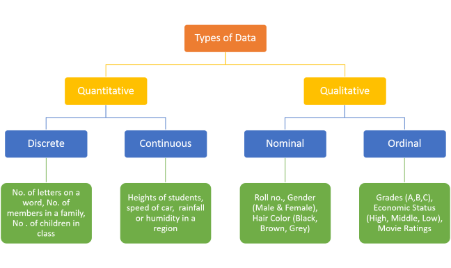

### Interval and Ratio Scale

Interval data has no absolute zero. e.g. A temperature of $0 ^{\circ}C$ does not mean absence of temperature. Similarly, 0:00 A.M. does not mean absense of any time.

Since Interval data lacks the absolute zero point, it makes direct comparisons of magnitude (e.g. A is twice as large as B) is impossible or meaningless. A good example is how we measure time of day, which is in an interval scale. We cannot say 10:00 A.M. is twice as long as 5:00 A.M. However, we can compare or take ratios of intervals between two value points such as we can say that the interval between 0:00 A.M. (midnight) and 10:00 A.M., which is a duration of 10 hours, is twice as long as the interval between 0:00 A.M. and 5:00 A.M., which is a duration of 5 hours. Another example is temperature. When we say 0°F, we do not mean zero heat. A temperature of 100°F is not twice as hot as 50°F.

Ratio data has a defined zero point. So having a value of 0 cm in length of any item means absence of item. Other examples of the ratio scale are measurements of weight, volume, area.

If two measurements are in ratio scale, then we can take ratios of those measurements with a meaningful interpretation. For example, because length is a ratio variable, a length of 100 cm is twice as lengthy as a length of 50 cm .

Another example is money. A sum of $ \$100 $ is twice as large as $\$50$. A sum of $\$0$ means absence of any money and is thus an absolute zero.

Following figure compares 4 major types of data or sometimes called as **4 scales of measurements**.

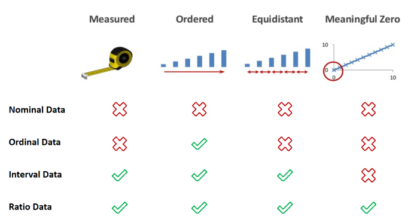

## Why Data Types are important?

Datatypes are an important concept because statistical methods can only be used with certain data types. You have to analyze continuous (Quantitative) data differently than categorical (Qualitative) data otherwise it would result in a wrong analysis. Therefore knowing the types of data you are dealing with, enables you to choose the correct method of analysis.

For example, When you are dealing with nominal and ordinal type of data, you collect information through frequencies, proportion, or percentage. To visualise nominal data you can use a pie chart or a bar chart.

In Data Science, we often use one hot encoding to transform nominal data into a numeric feature and one label encoding, to transform ordinal data into a numeric feature.

When you are dealing with continuous data, you can use the most methods to describe your data. You can summarise your data using percentiles, median, interquartile range, mean, mode, standard deviation, and range. To visualise continuous data, you can use a histogram or a box-plot.

We will get to know more about these statistical mathods further in the module.

# 0.2. Population vs Sample

**Population:** This is the totality, the complete list of observations, or all the data points about the subject under study.

**Sample:** A sample is a subset of a population, usually a small portion of the population that is being analyzed.

The population is the entire collection of measurements in which we are interested, and the sample is a smaller set of measurements selected from the population.

# 0.3. Descriptive and Inferential Statistics

The field of statistics can be defined as a specialized branch of mathematics that consists of frameworks and methodologies to collect, organize, analyze, interpret, and present data. Generally, this falls more under applied mathematics and borrows concepts from linear algebra, distributions, probability theory, and inferential methodologies. There are two major areas under statistics that are mentioned as follows:

- Descriptive Statistics
- Inferential Statistics

The core component of any statistical process is data. Hence typically data collection is done first, which could be in global terms, often called a **population** or a more restricted subset due to various constraints often knows as a **sample**. Samples are usually collected manually, from surveys, experiments, data stores, and observational studies. From this data, various analyses are carried out using statistical methods.

**Descriptive Statistics** is used to understand basic characteristics of the data using various aggregation and summarization measures to describe and understand the data better. These could be standard measures like mean, median, mode, skewness, kurtosis, standard deviation, variance, and so on. You can refer to any standard book on statistics to deep dive into these measures if you’re interested. Libraries and frameworks like pandas, scipy, and numpy in general help us compute descriptive statistics and summarize data easily in Python.

**Inferential Statistics** are used when we want to test hypothesis, draw inferences, and conclusions about various characteristics of our data sample or population. Frameworks and techniques like correlation, and regression analysis, forecasting, and predictions are typically used for any form of inferential statistics.

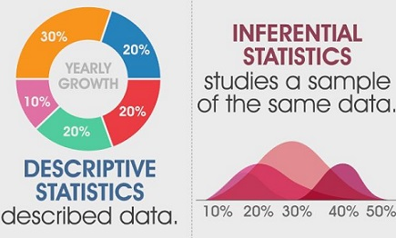